# Preparing MARINe raw data for power analysis

## Load packages

```r
library(tidyverse)
library(janitor)
library(here)
library(vegan)
```

# SWATH DATA

## Quick data tidy

```r
swath <- read_csv(here("data","amelia_ritger_cbs_ltm_data_20210601-swath.csv")) %>%
  clean_names() %>%
    rename("species" = "final_classification",
         "site"="intertidal_sitename") %>%
  select("site","site_code","survey_rep","year","month","transect","location","species","count")

sort(unique(swath$species))
```

```
## [1] "leptasterias spp"       "no swath species found" "patiria miniata"
## [4] "pisaster giganteus"     "pisaster ochraceus"
```

## Check out summary data

```r
swath_clean <- swath %>%
  filter(species!="no swath species found") %>%
  group_by(site, year, species) %>%
  summarize(tot_sp=sum(count))
```

## Look into some high numbers

```r
swath_lol <- swath %>%
  filter(species!="no swath species found",
         site=="Lompoc Landing",
         year=="2014")

#Confirm with MARINe summary data for swath counts
marine <- read_csv(here("data","amelia_ritger_cbs_summary_2020_1005-swath.csv")) %>%
  clean_names() %>%
  filter(intertidal_sitename=="Lompoc Landing",
         year=="2014")
```

Yep, my quick wrangling matches up with the MARINe summarized data

## Quick visualization

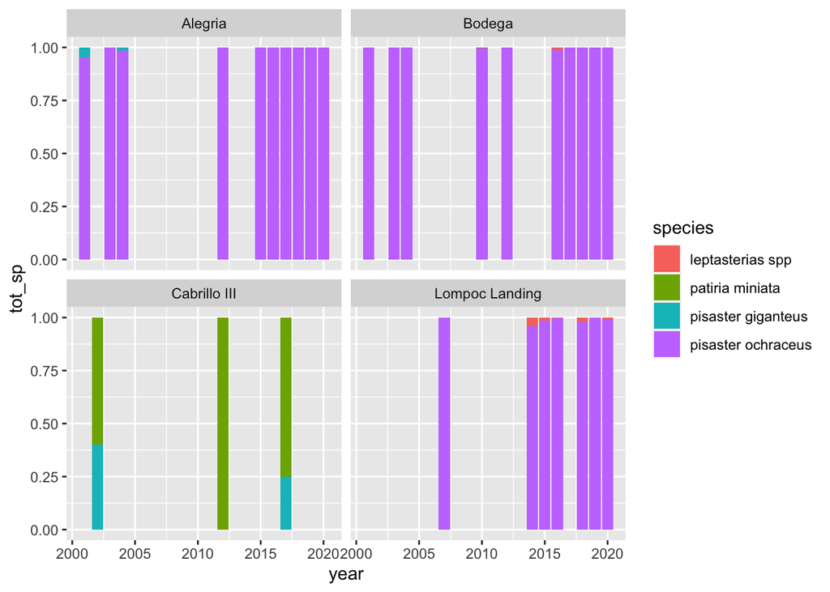

```r
ggplot(swath_clean, aes(fill=species, y=tot_sp, x=year)) +
  geom_bar(position="fill", stat="identity") +
  facet_wrap(~site)
```

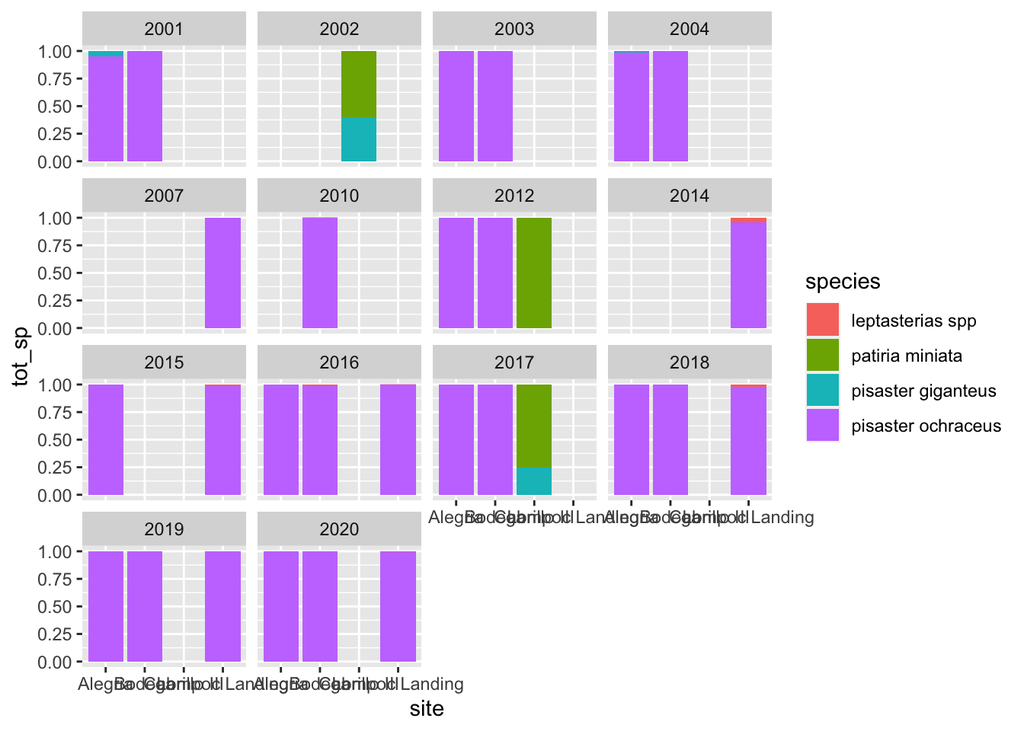

```r
#Look at it each year
ggplot(swath_clean, aes(fill=species, y=tot_sp, x=site)) +
  geom_bar(position="fill", stat="identity") +
  facet_wrap(~year)
```

```r
#+facet_wrap(~site)
```

I want to exclude Cabrillo (it’s SO different from the other sites) and compare only years where all three other sites were measured - so 2016, 2018, 2019, and 2020

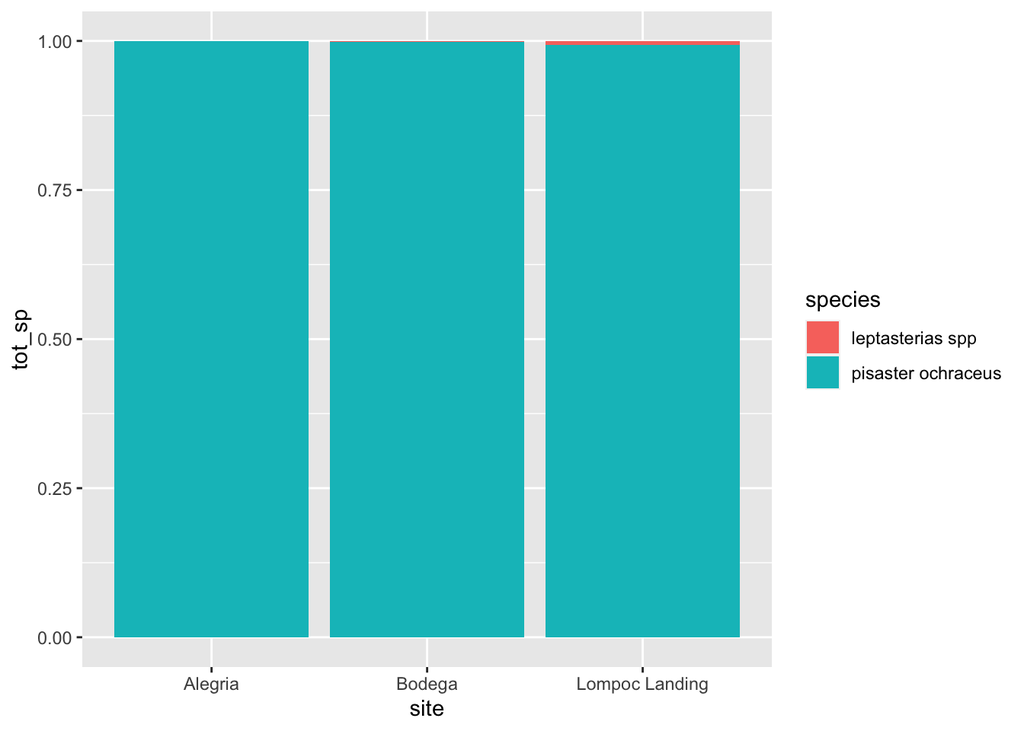

```r
swath_three <- swath_clean %>%
  filter(site!="Cabrillo III",
         year %in% c(2016, 2018, 2019, 2020))

ggplot(swath_three, aes(fill=species, y=tot_sp, x=site)) +
  geom_bar(position="fill", stat="identity")
```

### Damn, check out that (lack of diversity)!

# QUADRAT DATA

## Quick data tidy

```r
quad <- read_csv(here("data","amelia_ritger_cbs_ltm_data_20210601-quad.csv")) %>%
  clean_names() %>%
    rename("species" = "final_classification",
         "site"="intertidal_sitename") %>%
  select("site","survey_rep","year","month","transect","location","zone_code","species","count")
```

## Check out summary data

```r
sort(unique(quad$species))
```

```
##  [1] "acanthinucella spp"
##  [2] "alia spp"
##  [3] "amphissa columbiana"
##  [4] "amphissa versicolor"
##  [5] "californiconus californicus"
##  [6] "cancer antennarius"
##  [7] "cancer spp"
##  [8] "ceratostoma nuttalli"
##  [9] "crepipatella lingulata"
## [10] "epitonium tinctum"
## [11] "hemigrapsus nudus"
## [12] "homalopoma spp"
## [13] "kelletia kelletii"
## [14] "lacuna spp"
## [15] "leptasterias spp"
```

[output cut: 29 more lines]

```r
quad_clean <- quad %>%
  filter(species %in% c("acanthinucella spp","cancer antennarius","cancer spp", "kelletia kelletii", "leptasterias spp","nucella canaliculata","nucella emarginata; nucella ostrina","pachygrapsus crassipes","hemigrapsus nudus","pisaster ochraceus","tegula aureotincta","tegula brunnea","tegula eiseni","tegula funebralis","tegula gallina")) %>%
  group_by(site, year, species) %>%
  summarize(tot_sp=sum(count))
```

# In the future (when I have time) - check species list for predators I may have missed

## check it with MARINe summarized data

```r
marine <- read_csv(here("data", "amelia_ritger_cbs_summary_2020_1005-quad.csv")) %>%
  clean_names() %>%
  filter(intertidal_sitename=="Alegria",
         year=="2001")
```

Yep, looks good

## Plot it up

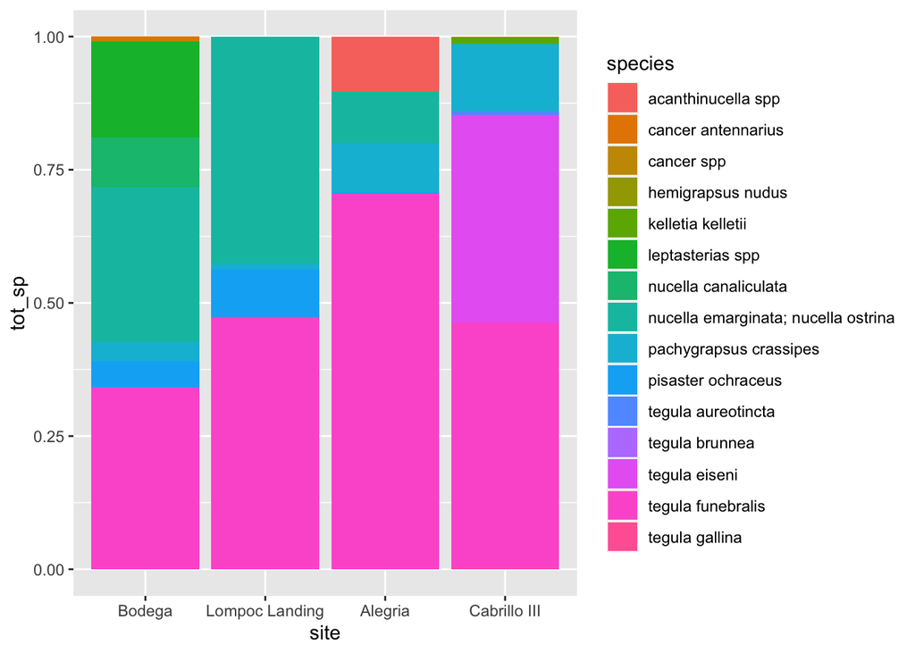

```r
ggplot(quad_clean, aes(fill=species, y=tot_sp, x=site)) +
  geom_bar(position="fill", stat="identity") + #facet_wrap(~year)
  scale_x_discrete(limits = c("Bodega", "Lompoc Landing", "Alegria", "Cabrillo III"))
```

```r
ggsave("figures/composition_site.png")
```

## Run an NMDS on the data to compare community composition across sites

```r
#example community-by-species matrix, nmds
set.seed(2)
community_matrix=matrix(
   sample(1:100,300,replace=T),nrow=10,
   dimnames=list(paste("community",1:10,sep=""),paste("sp",1:30,sep="")))

example_NMDS=metaMDS(community_matrix, # Our community-by-species matrix
                     k=2) # The number of reduced dimensions
```

```
## Square root transformation
## Wisconsin double standardization
## *** Solution reached
```

```r
#do it with my data
quad_matrix_df <- quad %>%
  filter(species %in% c("acanthinucella spp","cancer antennarius","cancer spp", "kelletia kelletii", "leptasterias spp","nucella canaliculata","nucella emarginata; nucella ostrina","pachygrapsus crassipes","hemigrapsus nudus","pisaster ochraceus","tegula aureotincta","tegula brunnea","tegula eiseni","tegula funebralis","tegula gallina")) %>%
  group_by(site, species) %>%
  summarize(tot_sp=sum(count)) %>%
  pivot_wider(names_from=species, values_from=tot_sp) %>%
  replace(is.na(.), 0)

#convert df to matrix for NMDS
quad_matrix <- data.matrix(quad_matrix_df)
rownames(quad_matrix) <- c("Alegria", "Bodega", "Cabrillo III", "Lompoc Landing") #rename matrix row names to sites
quad_matrix <- quad_matrix[,-1] #remove first column

#run the NMDS
quad_nmds <- metaMDS(quad_matrix, k=2) #k is the number of reduced dimensions
```

```
## Square root transformation
## Wisconsin double standardization
## *** No convergence -- monoMDS stopping criteria:
##     20: stress < smin
```

```r
quad_nmds
```

```
##
## Call:
## metaMDS(comm = quad_matrix, k = 2)
##
## global Multidimensional Scaling using monoMDS
##
## Data:     wisconsin(sqrt(quad_matrix))
## Distance: bray
##
## Dimensions: 2
## Stress:     0
## Stress type 1, weak ties
## No convergent solutions - best solution after 20 tries
## Scaling: centring, PC rotation
## Species: expanded scores based on 'wisconsin(sqrt(quad_matrix))'
```

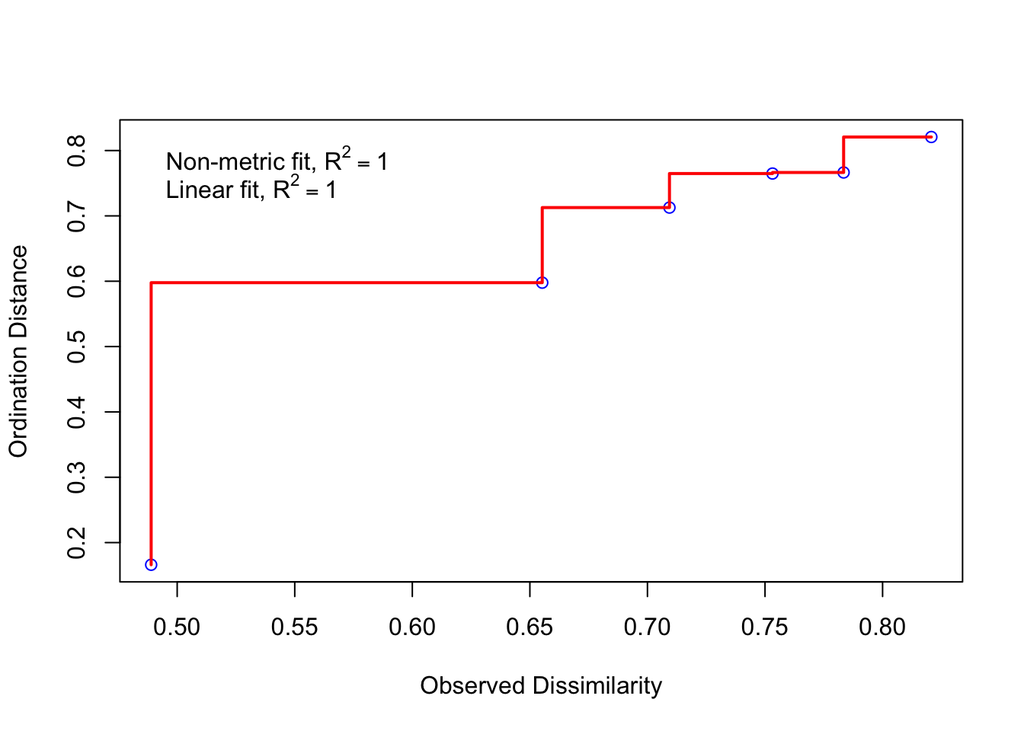

```r
stressplot(quad_nmds)
```

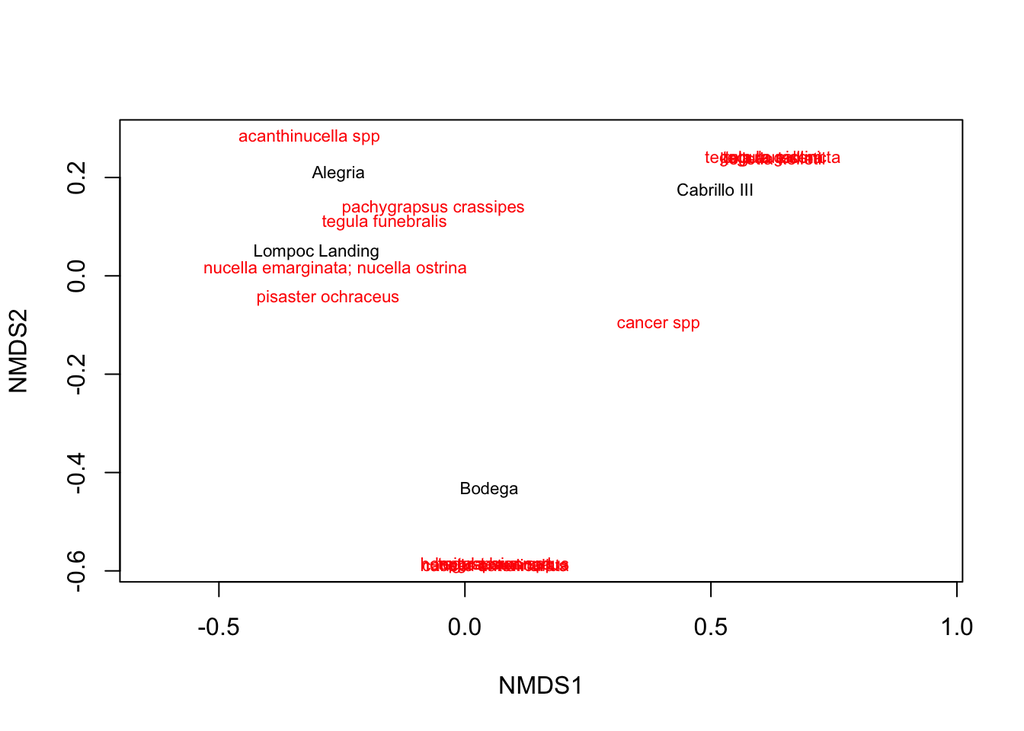

```r
plot(quad_nmds, type="t")
```

# Run power analysis on only species found at all sites across sites

## Nucella

```r
quad_nucella <- quad %>%
  filter(species %in% c("nucella canaliculata", "nucella emarginata; nucella ostrina", "acanthinucella spp"),
         survey_rep<ifelse(site=="Cabrillo III", 5, 2)) %>% #Cabrillo only counted nucella on the 4th replicate of surveys so make ifelse
  group_by(site) %>%
  summarize(tot=n(),
            avg=mean(count),
            var=var(count))

nucella_avg <- quad_nucella %>%
  pull(avg)
nucella_var <- quad_nucella %>%
  pull(var) %>%
  mean()
nucella_n <- quad_nucella %>%
  pull(tot) %>%
  mean() %>%
  ceiling() #round up to whole number for simulation
```

Use simulation to run power analysis for comparing nucella across sites

```r
n.sim <- 10000         ## number of simulations
mu    <- nucella_avg  ## site means
sigma2<- nucella_var  ## error variance (averaged across all sites) assumption: 7.5
n     <- nucella_n    ## number of observations per site (mean across all years: 14)

n     <- 30           # coerce new number for replicate size
g     <- length(mu)
group <- factor(rep(LETTERS[1:g], each = n))

results <- numeric(n.sim) ## vector to store results in

for(i in 1:n.sim){
  ## Simulate new response, build data set
  y <- rnorm(n * g, mean = rep(mu, each = n), sd = sqrt(sigma2))
  data <- data.frame(y = y, group = group)

  ## Fit one-way ANOVA model
  fit  <- aov(y ~ group, data = data)

  ## Extract result of global F-test
  results[i] <- summary(fit)[[1]][1, "Pr(>F)"] < 0.05 ## 1 = reject
}

mean(results) ## proportion of simulation runs that rejected H_0
```

```
## [1] 0.8038
```

n = 30, 80%

## Pachygraspus

```r
quad_pachy <- quad %>%
  filter(species %in% c("pachygrapsus crassipes"),
         survey_rep==ifelse(site=="Cabrillo III", 4,
                            ifelse(site=="Bodega", 7,
                                   ifelse(site=="Alegria", 6,1)))) %>%
  group_by(site) %>%
  summarize(tot=n(),
            avg=mean(count),
            var=var(count))

pachy_avg <- quad_pachy %>%
  pull(avg)
pachy_var <- quad_pachy %>%
  pull(var) %>%
  mean()
pachy_n <- quad_pachy %>%
  pull(tot) %>%
  mean() %>%
  ceiling() #round up to whole number for simulation
```

Use simulation to run power analysis for comparing pachygraspus across sites

```r
n.sim <- 10000         ## number of simulations
mu    <- pachy_avg  ## site means
sigma2<- pachy_var  ## error variance (averaged across all sites) assumption: 7.5
n     <- pachy_n    ## number of observations per site (mean across all years: 31)

n     <- 25           # coerce new number for replicate size
g     <- length(mu)
group <- factor(rep(LETTERS[1:g], each = n))

results <- numeric(n.sim) ## vector to store results in

for(i in 1:n.sim){
  ## Simulate new response, build data set
  y <- rnorm(n * g, mean = rep(mu, each = n), sd = sqrt(sigma2))
  data <- data.frame(y = y, group = group)

  ## Fit one-way ANOVA model
  fit  <- aov(y ~ group, data = data)

  ## Extract result of global F-test
  results[i] <- summary(fit)[[1]][1, "Pr(>F)"] < 0.05 ## 1 = reject
}

mean(results) ## proportion of simulation runs that rejected H_0
```

```
## [1] 0.8047
```

## Tegula

```r
quad_tegula <- quad %>%
  filter(species %in% c("tegula funebralis"),
         survey_rep==ifelse(site=="Cabrillo III", 4,
                            ifelse(site=="Bodega", 7,
                                   ifelse(site=="Alegria", 4, 1)))) %>%
  group_by(site) %>%
  summarize(tot=n(),
            avg=mean(count),
            var=var(count))

tegula_avg <- quad_tegula %>%
  pull(avg)
tegula_var <- quad_tegula %>%
  pull(var) %>%
  mean()
tegula_n <- quad_tegula %>%
  pull(tot) %>%
  mean() %>%
  ceiling() #round up to whole number for simulation
```

Use simulation to run power analysis for comparing tegula across sites

```r
n.sim <- 10000         ## number of simulations
mu    <- tegula_avg  ## site means
sigma2<- tegula_var  ## error variance (averaged across all sites) assumption: 7.5
n     <- tegula_n    ## number of observations per site (mean across all years: 31)

n     <- 26           # (if I am running two sets of surveys in a year)
g     <- length(mu)
group <- factor(rep(LETTERS[1:g], each = n))

results <- numeric(n.sim) ## vector to store results in

for(i in 1:n.sim){
  ## Simulate new response, build data set
  y <- rnorm(n * g, mean = rep(mu, each = n), sd = sqrt(sigma2))
  data <- data.frame(y = y, group = group)

  ## Fit one-way ANOVA model
  fit  <- aov(y ~ group, data = data)

  ## Extract result of global F-test
  results[i] <- summary(fit)[[1]][1, "Pr(>F)"] < 0.05 ## 1 = reject
}

mean(results) ## proportion of simulation runs that rejected H_0
```

```
## [1] 0.8022
```

n = 26, 80%

Traditional ANOVA power test (let’s use Tegula as an example)

```r
library(pwr)
pwr.anova.test(k = 4, f = 0.25, sig.level = 0.01 , power = 0.8) # 25% effect size
```

```
##
##      Balanced one-way analysis of variance power calculation
##
##               k = 4
##               n = 63.2582
##               f = 0.25
##       sig.level = 0.01
##           power = 0.8
##
## NOTE: n is number in each group
```

Damn, need an n = 63 for 80% power

So… at least using my janky power analyses methods, I’ll need to do all 11 quadrat replicates to measure significant differences *between* sites

Now let’s look at replication needed within a site to capture sufficient variation

# Run power analysis on Tegula (since it has the most intra-site variation) for each site

## Bodega

```r
quad_intra_b <- quad %>%
  filter(species %in% c("tegula funebralis"),
         site == "Bodega") %>%
  group_by(year) %>%
  summarize(tot=n(),
            avg=mean(count),
            var=var(count))

tegula_avg <- quad_intra_b %>%
  pull(avg)
tegula_var <- quad_intra_b %>%
  pull(var) %>%
  mean()
tegula_n <- quad_intra_b %>%
  pull(tot) %>%
  mean() %>%
  ceiling() #round up to whole number for simulation
```

Use simulation to run power analysis for comparing tegula across years sites

```r
n.sim <- 10000         ## number of simulations
mu    <- tegula_avg  ## site means
sigma2<- tegula_var  ## error variance (averaged across all sites) assumption: 7.5
n     <- tegula_n    ## number of observations per site (mean across all years: 9)

n     <- 24           # (if I am running two sets of surveys in a year)
g     <- length(mu)
group <- factor(rep(LETTERS[1:g], each = n))

results <- numeric(n.sim) ## vector to store results in

for(i in 1:n.sim){
  ## Simulate new response, build data set
  y <- rnorm(n * g, mean = rep(mu, each = n), sd = sqrt(sigma2))
  data <- data.frame(y = y, group = group)

  ## Fit one-way ANOVA model
  fit  <- aov(y ~ group, data = data)

  ## Extract result of global F-test
  results[i] <- summary(fit)[[1]][1, "Pr(>F)"] < 0.05 ## 1 = reject
}

mean(results) ## proportion of simulation runs that rejected H_0
```

```
## [1] 0.817
```

n = 24 for 80% power at BML

## Alegria

```r
quad_intra_a <- quad %>%
  filter(species %in% c("tegula funebralis"),
         site == "Alegria") %>%
  group_by(year) %>%
  summarize(tot=n(),
            avg=mean(count),
            var=var(count))

tegula_avg <- quad_intra_a %>%
  pull(avg)
tegula_var <- quad_intra_a %>%
  pull(var) %>%
  mean()
tegula_n <- quad_intra_a %>%
  pull(tot) %>%
  mean() %>%
  ceiling() #round up to whole number for simulation
```

Use simulation to run power analysis for comparing tegula across years

```r
n.sim <- 10000         ## number of simulations
mu    <- tegula_avg  ## site means
sigma2<- tegula_var  ## error variance (averaged across all sites) assumption: 7.5
n     <- tegula_n    ## number of observations per site (mean across all years: 15)

n     <- 28           # (if I am running two sets of surveys in a year)
g     <- length(mu)
group <- factor(rep(LETTERS[1:g], each = n))

results <- numeric(n.sim) ## vector to store results in

for(i in 1:n.sim){
  ## Simulate new response, build data set
  y <- rnorm(n * g, mean = rep(mu, each = n), sd = sqrt(sigma2))
  data <- data.frame(y = y, group = group)

  ## Fit one-way ANOVA model
  fit  <- aov(y ~ group, data = data)

  ## Extract result of global F-test
  results[i] <- summary(fit)[[1]][1, "Pr(>F)"] < 0.05 ## 1 = reject
}

mean(results) ## proportion of simulation runs that rejected H_0
```

```
## [1] 0.8053
```

n = 28 for 80% power at Alegria

## Cabrillo

```r
quad_intra_c <- quad %>%
  filter(species %in% c("tegula funebralis"),
         site == "Cabrillo III") %>%
  group_by(year) %>%
  summarize(tot=n(),
            avg=mean(count),
            var=var(count))

tegula_avg <- quad_intra_c %>%
  pull(avg)
tegula_var <- quad_intra_c %>%
  pull(var) %>%
  mean()
tegula_n <- quad_intra_c %>%
  pull(tot) %>%
  mean() %>%
  ceiling() #round up to whole number for simulation
```

Use simulation to run power analysis for comparing tegula across years

```r
n.sim <- 10000         ## number of simulations
mu    <- tegula_avg  ## site means
sigma2<- tegula_var  ## error variance (averaged across all sites) assumption: 7.5
n     <- tegula_n    ## number of observations per site (mean across all years: 6)

n     <- 9           # (if I am running two sets of surveys in a year)
g     <- length(mu)
group <- factor(rep(LETTERS[1:g], each = n))

results <- numeric(n.sim) ## vector to store results in

for(i in 1:n.sim){
  ## Simulate new response, build data set
  y <- rnorm(n * g, mean = rep(mu, each = n), sd = sqrt(sigma2))
  data <- data.frame(y = y, group = group)

  ## Fit one-way ANOVA model
  fit  <- aov(y ~ group, data = data)

  ## Extract result of global F-test
  results[i] <- summary(fit)[[1]][1, "Pr(>F)"] < 0.05 ## 1 = reject
}

mean(results) ## proportion of simulation runs that rejected H_0
```

```
## [1] 0.8498
```

n = 9 for 80% power at Cabrillo III

# Run power analysis on Tegula at each year within Alegria

## 2001

```r
quad_intra_2001 <- quad %>%
  filter(species %in% c("tegula funebralis"),
         site == "Alegria",
         year == "2001") %>%
  group_by(transect) %>%
  summarize(tot=n(),
            avg=mean(count),
            var=var(count)) %>%
  add_row(transect = 3, tot = 0, avg = 0, var = 0) %>%
  replace(is.na(.), 0)


tegula_avg <- quad_intra_2001 %>%
  pull(avg)
tegula_var <- quad_intra_2001 %>%
  pull(var) %>%
  mean()
tegula_n <- quad_intra_2001 %>%
  pull(tot) %>%
  mean() %>%
  ceiling() #round up to whole number for simulation
```

## 2012

```r
quad_intra_2012 <- quad %>%
  filter(species %in% c("tegula funebralis"),
         site == "Alegria",
         year == "2012") %>%
  group_by(transect) %>%
  summarize(tot=n(),
            avg=mean(count),
            var=var(count)) %>%
  replace(is.na(.), 0)

tegula_avg <- quad_intra_2012 %>%
  pull(avg)
tegula_var <- quad_intra_2012 %>%
  pull(var) %>%
  mean()
tegula_n <- quad_intra_2012 %>%
  pull(tot) %>%
  mean() %>%
  ceiling() #round up to whole number for simulation
```

Use simulation to run power analysis for comparing tegula across years

```r
n.sim <- 10000         ## number of simulations
mu    <- tegula_avg  ## transect means
sigma2<- tegula_var  ## error variance (averaged across all transects) assumption: 7.5
n     <- tegula_n    ## number of observations per transect (n=3 for 2012, n=2 for 2001)

n     <- 2           # (if I am running two sets of surveys in a year)
g     <- length(mu)
group <- factor(rep(LETTERS[1:g], each = n))

results <- numeric(n.sim) ## vector to store results in

for(i in 1:n.sim){
  ## Simulate new response, build data set
  y <- rnorm(n * g, mean = rep(mu, each = n), sd = sqrt(sigma2))
  data <- data.frame(y = y, group = group)

  ## Fit one-way ANOVA model
  fit  <- aov(y ~ group, data = data)

  ## Extract result of global F-test
  results[i] <- summary(fit)[[1]][1, "Pr(>F)"] < 0.05 ## 1 = reject
}

mean(results) ## proportion of simulation runs that rejected H_0
```

```
## [1] 0.186
```

# SUMMARY

I don’t really trust these power analyses, so I am going to pick a year for each site with a lot of variation and eye ball it to see how many transects I should be running, AND whether I need to run high and mid transects for Tegula and nucella

# BML

## Tegula and Nucella, 2017

```r
bml_t <- quad %>%
  filter(species %in% c("tegula funebralis"),
         site == "Bodega",
         year == "2017")

bml_n <- quad %>%
  filter(species %in% c("nucella canaliculata", "nucella emarginata; nucella ostrina", "acanthinucella spp"),
         site == "Bodega",
         year == "2017")
```

Definitely need high and mid quadrats for Tegula Don’t need all 11 transects most likely

Nucella is definitely only in mid (and low) Don’t need all 11 transects (maybe half of them)

# LOL

```r
lol_t <- quad %>%
  filter(species %in% c("tegula funebralis"),
         site == "Lompoc Landing")

lol_n <- quad %>%
  filter(species %in% c("nucella canaliculata", "nucella emarginata; nucella ostrina", "acanthinucella spp"),
         site == "Lompoc Landing")
```

Definitely need high and mid quadrats for Tegula Don’t need all 11 transects most likely

Nucella is definitely only in mid (and low) Don’t need all 11 transects most likely

# Alegria

## Tegula and nucella, 2012

```r
alg_t <- quad %>%
  filter(species %in% c("tegula funebralis"),
         site == "Alegria",
         year == "2012")

alg_n <- quad %>%
  filter(species %in% c("nucella canaliculata", "nucella emarginata; nucella ostrina", "acanthinucella spp"),
         site == "Alegria",
         year == "2012")
```

Definitely need high and mid quadrats (and low?!) for Tegula Probably need all 11 transects in high to capture Tegula, Tegula can be super spotty but also really abundant when it is found in mid

Can capture Nucella sometimes in high, and definitely mid In high, would need over half of high quadrats to get Nucella at all In mid, would probably only need at least half quadrats to capture Nucella variation

# Cabrillo III

## Tegula and nucella, 2012/2017

```r
cnm_t <- quad %>%
  filter(species %in% c("tegula funebralis"),
         site == "Cabrillo III",
         year == "2017")

cnm_n <- quad %>%
  filter(species %in% c("nucella canaliculata", "nucella emarginata; nucella ostrina", "acanthinucella spp"),
         site == "Cabrillo III",
         year == "2017")

#look at all species at CNM in 2017
cnm <- quad %>%
  filter(site == "Cabrillo III",
         year == "2017")
```

Tegula is entirely in high zone at Cabrillo, need at least half of quadrats to capture Tegula populations (ideally run all 11)

Need some mid quadrats to capture pachygraspus, need probably all high quadrats to capture nucella

# Action items

## BML:

Run fewer than 11 quadrats in high, run nearly half of the 11 quadrats in mid

## LOL:

Run fewer than 11 quadrats in high, run fewer than 11 quadrats in mid

## Cabrillo III:

Run all 11 quadrats in high, half quadrats in mid for pachygraspus